# Introducton to missing values

Materials from Datacamp summarized by Eleanor Zhang

Claim: all materials are summarized based on Datacamp Learning Track of “Intermediate Tidyverse Toolbox”.

Load packaged at need.

```r
library(tidyverse)
library(naniar) # deal with missing value
```

# 1 Check missing values

Define missing values: From human perspective, it means the the value should have been recorded but not. In R language, missing values can be coded as “NA”, “NaN”.

Create a vector containing NA (Not Available)

```r
x <- c(1, NA, 3, NA, NA, 5)
```

Check if there is any NA present

```r
anyNA(x) # return true or false
```

```
## [1] TRUE
```

Check any NA at each position

```r
is.na(x) # return a logical vector
```

```
## [1] FALSE  TRUE FALSE  TRUE  TRUE FALSE
```

Count number of missing values

```r
# use base r
sum(is.na(x)) # logical vector can be added up
```

```
## [1] 3
```

```r
# use naniar package
n_miss(x)
```

```
## [1] 3
```

```r
prop_miss(x)
```

```
## [1] 0.5
```

“NaN”: not a number, R interpret this as missing value

```r
anyNA(NaN)
```

```
## [1] TRUE
```

```r
sqrt(-1) # example of how NaN is created
```

[output not shown]

“NULL”: an empty value, but not missing (think about an empty bottle is not “missing” water)

```r
anyNA(NULL)
```

```
## [1] FALSE
```

“Inf”: infinite value, not missing

```r
anyNA(Inf)
```

```
## [1] FALSE
```

```r
10/0 # example of Inf
```

```
## [1] Inf
```

```r
NA | TRUE
```

```
## [1] TRUE
```

```r
NA | FALSE
```

```
## [1] NA
```

# 2 Behaviors of missing values

Calculation behavior with NA:

```r
sum(x)
```

```
## [1] NA
```

```r
# these two are different
NA + NaN
```

```
## [1] NA
```

```r
NaN + NA
```

```
## [1] NaN
```

# 3 Summary of missingness

For a new dataset, we need to check if there any any missing values and how many there are. Take `msleep` dataset from ggplot2 package as a demo. It is taken from a study aiming to expand understanding about mammalian sleep. More information about the variables can be found using `?msleep`.

```r
data("msleep")
str(msleep)
```

```
## Classes 'tbl_df', 'tbl' and 'data.frame':    83 obs. of  11 variables:
##  $ name        : chr  "Cheetah" "Owl monkey" "Mountain beaver" "Greater short-tailed shrew" ...
##  $ genus       : chr  "Acinonyx" "Aotus" "Aplodontia" "Blarina" ...
##  $ vore        : chr  "carni" "omni" "herbi" "omni" ...
##  $ order       : chr  "Carnivora" "Primates" "Rodentia" "Soricomorpha" ...
##  $ conservation: chr  "lc" NA "nt" "lc" ...
##  $ sleep_total : num  12.1 17 14.4 14.9 4 14.4 8.7 7 10.1 3 ...
##  $ sleep_rem   : num  NA 1.8 2.4 2.3 0.7 2.2 1.4 NA 2.9 NA ...
##  $ sleep_cycle : num  NA NA NA 0.133 0.667 ...
##  $ awake       : num  11.9 7 9.6 9.1 20 9.6 15.3 17 13.9 21 ...
##  $ brainwt     : num  NA 0.0155 NA 0.00029 0.423 NA NA NA 0.07 0.0982 ...
##  $ bodywt      : num  50 0.48 1.35 0.019 600 ...
```

## 3.1 Basics

```r
# count total number of missing values
n_miss(msleep)
```

```
## [1] 136
```

```r
# count total number of complete values
n_complete(msleep)
```

```
## [1] 777
```

```r
# count number of missing value on each variable
map_df(msleep, prop_miss)
```

```
## # A tibble: 1 x 11
##    name genus   vore order conservation sleep_total sleep_rem sleep_cycle
##   <dbl> <dbl>  <dbl> <dbl>        <dbl>       <dbl>     <dbl>       <dbl>
## 1     0     0 0.0843     0        0.349           0     0.265       0.614
## # … with 3 more variables: awake <dbl>, brainwt <dbl>, bodywt <dbl>
```

```r
map_df(msleep, prop_complete)
```

```
## # A tibble: 1 x 11
##    name genus  vore order conservation sleep_total sleep_rem sleep_cycle
##   <dbl> <dbl> <dbl> <dbl>        <dbl>       <dbl>     <dbl>       <dbl>
## 1     1     1 0.916     1        0.651           1     0.735       0.386
## # … with 3 more variables: awake <dbl>, brainwt <dbl>, bodywt <dbl>
```

## 3.2 Sumarize missing values in detail

Basic summaries using `n_miss()` and `n_complete()`, but need more detailed summaries of missingness, which works smoothly with `group_by` in dplyr package.

### 3.2.1 `miss_var_summary()`:

return number of and percent of missing values in each variable

```r
miss_var_summary(msleep)
```

```
## # A tibble: 11 x 3
##    variable     n_miss pct_miss
##    <chr>         <int>    <dbl>
##  1 sleep_cycle      51    61.4
##  2 conservation     29    34.9
##  3 brainwt          27    32.5
##  4 sleep_rem        22    26.5
##  5 vore              7     8.43
##  6 name              0     0
##  7 genus             0     0
##  8 order             0     0
##  9 sleep_total       0     0
## 10 awake             0     0
## 11 bodywt            0     0
```

### 3.2.2 `miss_case_summary()`:

return number of and percent of missing values in each row; case is the row index; here only show the first 6 rows

```r
miss_case_summary(msleep) %>% arrange(case) %>% head()
```

```
## # A tibble: 6 x 3
##    case n_miss pct_miss
##   <int>  <int>    <dbl>
## 1     1      3     27.3
## 2     2      2     18.2
## 3     3      2     18.2
## 4     4      0      0
## 5     5      0      0
## 6     6      2     18.2
```

### 3.2.3 `miss_var_table()`:

column wise summary

```r
miss_var_table(msleep)
```

```
## # A tibble: 6 x 3
##   n_miss_in_var n_vars pct_vars
##           <int>  <int>    <dbl>
## 1             0      6    54.5
## 2             7      1     9.09
## 3            22      1     9.09
## 4            27      1     9.09
## 5            29      1     9.09
## 6            51      1     9.09
```

Read result: there are 6 variables (54.5% out of total variables) without any missing values, 1 variable with 7 missing values, etc.

### 3.2.4 `miss_case_table()`:

row-wise summary

```r
miss_case_table(msleep)
```

```
## # A tibble: 6 x 3
##   n_miss_in_case n_cases pct_cases
##            <int>   <int>     <dbl>
## 1              0      20     24.1
## 2              1      19     22.9
## 3              2      24     28.9
## 4              3      13     15.7
## 5              4       5      6.02
## 6              5       2      2.41
```

Read result: there are 20 rows (24.1% of total rows) that are complete.

## 3.3 Find missingness pattern

### 3.3.1 `miss_var_span()`:

Calculate number and percentage of missing values in repeating span, useful to detect repeated missing pattern. This is usually useful for time dependent variable and time series data, such as monthly or weekly.

```r
miss_var_span(msleep,
              var = vore, # for this variable
              span_every = 20) # per 20 rows
```

```
## # A tibble: 5 x 5
##   span_counter n_miss n_complete prop_miss prop_complete
##          <int>  <int>      <dbl>     <dbl>         <dbl>
## 1            1      1         19      0.05          0.95
## 2            2      0         20      0             1
## 3            3      3         17      0.15          0.85
## 4            4      3         17      0.15          0.85
## 5            5      0         20      0             1
```

Read result: span_counter = 1 refers to the first 20 rows of data; there is 1 value missing in the first 20 rows and 19 values are complete in variable “vore”.

### 3.3.2 `miss_var_run()`

Thi is “runs” of missing data for column wise. This is useful to detect missingness pattern for a given variable:

```r
miss_var_run(msleep, sleep_rem) %>% head() # result of first 6 rows
```

```
## # A tibble: 6 x 2
##   run_length is_na
##        <int> <chr>
## 1          1 missing
## 2          6 complete
## 3          1 missing
## 4          1 complete
## 5          1 missing
## 6         10 complete
```

Read result: The first value of sleep_rem is missing, the next 6 values are complete …

## 3.4 Summaries with `group_by`

These summary functions can work easily with dplyr package. For example, `group_by()` allows summary of missingness within specified grouping variable:

```r
msleep %>%
  group_by(vore) %>% # carnivore, omnivore or herbivore
  miss_var_table()
```

```
## # A tibble: 22 x 4
##    vore  n_miss_in_var n_vars pct_vars
##    <chr>         <int>  <int>    <dbl>
##  1 carni             0      6       60
##  2 carni             5      1       10
##  3 carni             9      1       10
##  4 carni            10      1       10
##  5 carni            14      1       10
##  6 omni              0      6       60
##  7 omni              2      1       10
##  8 omni              3      1       10
##  9 omni              9      1       10
## 10 omni             11      1       10
## # … with 12 more rows
```

Read result: This tabular summarizes missingness pattern in the group of carnivore, omnivore or herbivore respectively. For example, carnivores has 6 variables that are complete.

Same with row-wise summary:

```r
msleep %>%
  group_by(vore) %>% # carnivore, omnivore or herbivore
  miss_case_table()
```

```
## # A tibble: 21 x 4
##    vore  n_miss_in_case n_cases pct_cases
##    <chr>          <int>   <int>     <dbl>
##  1 carni              0       3     15.8
##  2 carni              1       3     15.8
##  3 carni              2       5     26.3
##  4 carni              3       7     36.8
##  5 carni              4       1      5.26
##  6 omni               0       5     25
##  7 omni               1       8     40
##  8 omni               2       5     25
##  9 omni               3       1      5
## 10 omni               4       1      5
## # … with 11 more rows
```

Read result: In carnivores, 3 rows or say cases are complete.

# 4 Visualize missing values

Naniar provides a bunch of missing visualization functions in which each corresponds to a missingness summary introduced above.

We could obtain a quick overview of missings in a dataset by `vis_miss()`: This function generate a heatmap of missingness, providing amount of missing in each variable and the location of missingness. We can also sort amount of missingness among variables by `sort_miss = TRUE`.

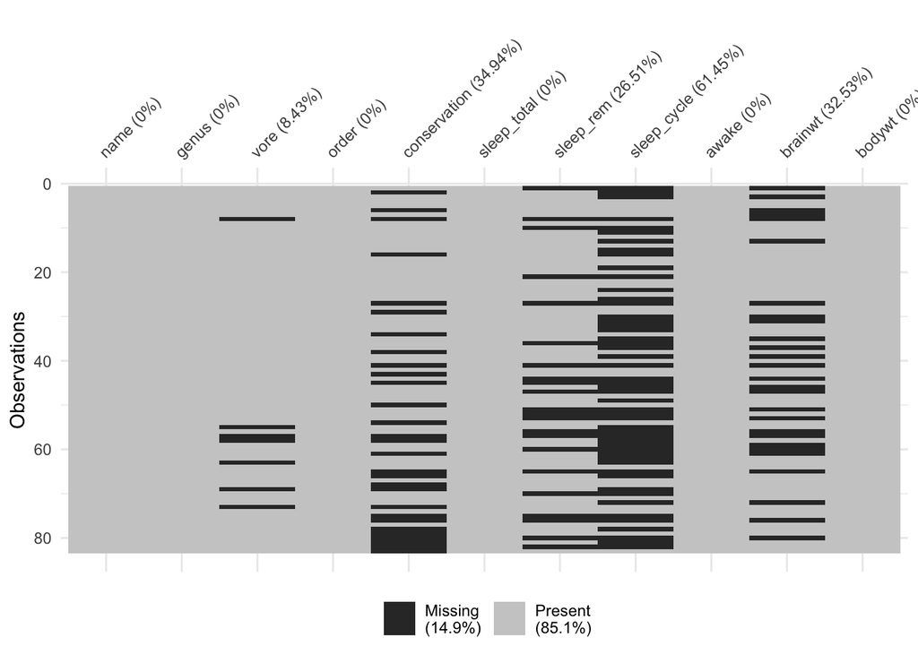

```r
vis_miss(msleep)
```

This function can also visualize missings in cluster if specified. It rearrange the rows to place common missings adajenct in a cluster.

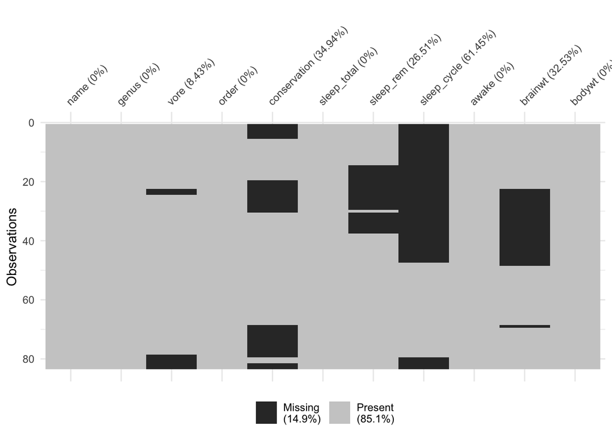

```r
vis_miss(msleep, cluster = TRUE)
```

Look at missings in variables and cases/rows. This two functions is equivalent to visualize the `miss_var_summary()` and `miss_case_summary()` output with ordering from high to low. The ordering can be turned off as following.

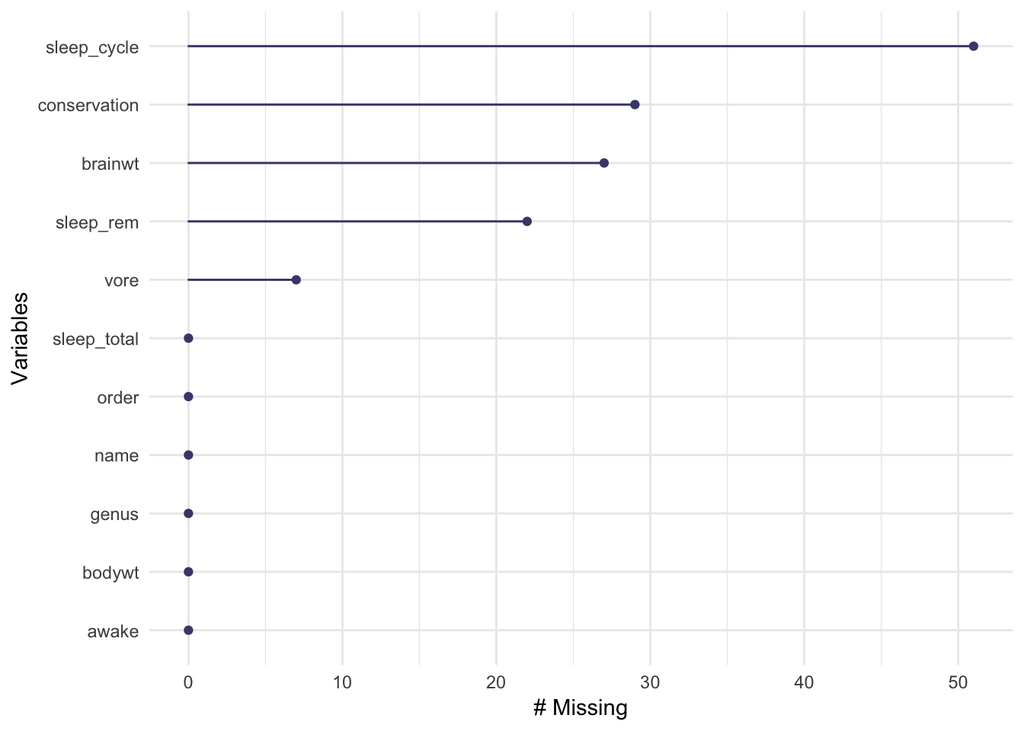

```r
gg_miss_var(msleep)
```

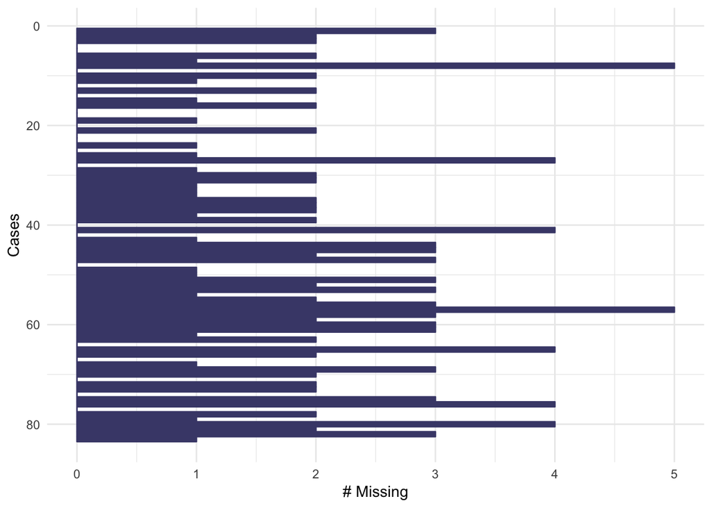

```r
gg_miss_case(msleep, order_cases = FALSE) # rows are not rearranged
```

Look at missings in variables and cases/rows between groups. The example shows missings of each variable in each “vore” group. The dominant missing values in carnivores and herbivores are sleep cycle.

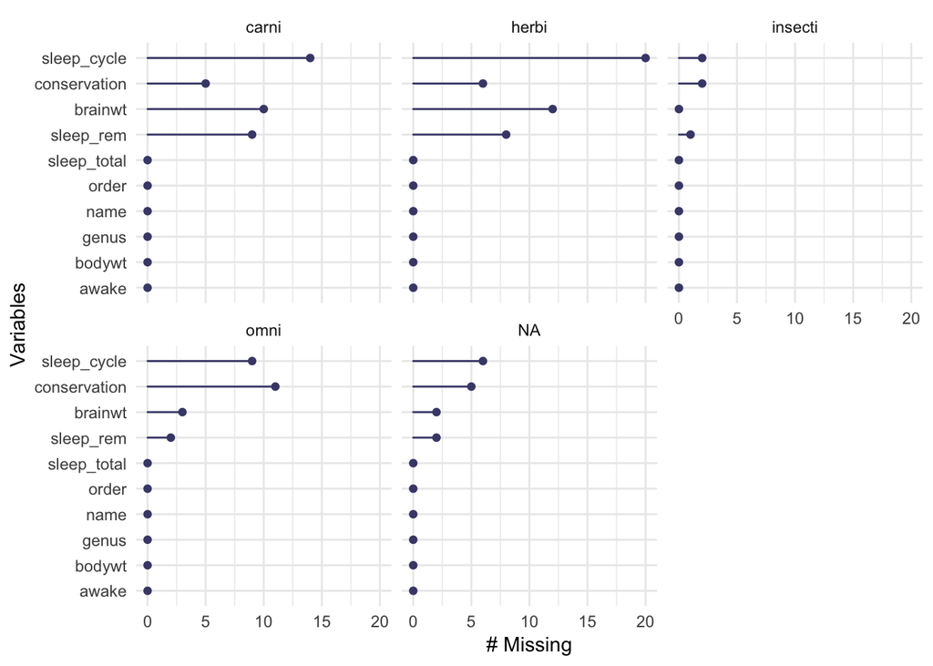

```r
gg_miss_var(msleep, facet = vore) # vore has missings itself
```

look at the missingness of variables that co-occur in cases. For example, the leftmost vertical column says 10 cases have missings in both weight and sleep cylce.

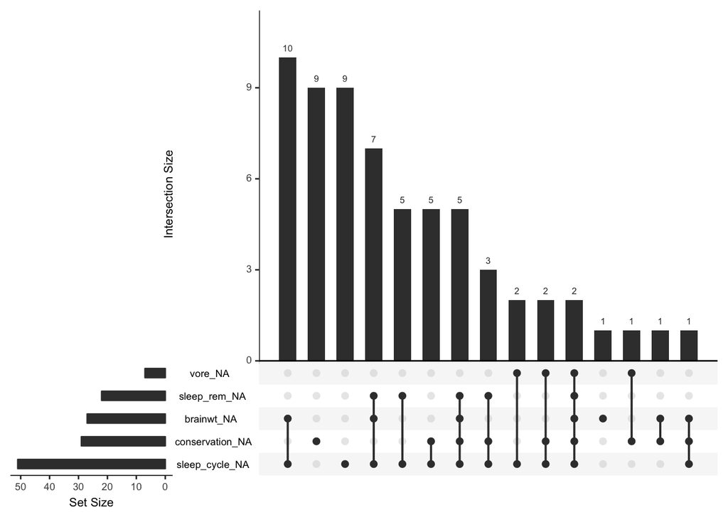

```r
gg_miss_upset(msleep)
```

Compare missingness of each variable between different groups. This function also generate a heatmap. The colors of the legend dictate amount of missingness of given variable in the group defined on x axis. For example, over 60% of sleep cycle record is missing in carnivores.

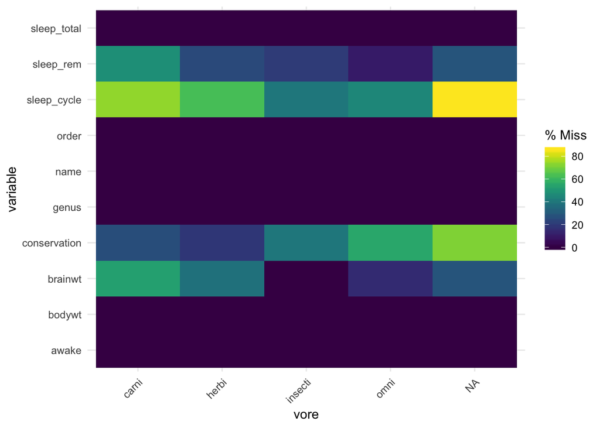

```r
gg_miss_fct(msleep, fct = vore)
```

Visualize spans of missingness, which is analog to `miss_var_span()`. This function also support faceting. Here we plot the spans (every 10 rows) of missings in rem sleep hours and facet by “vore”.

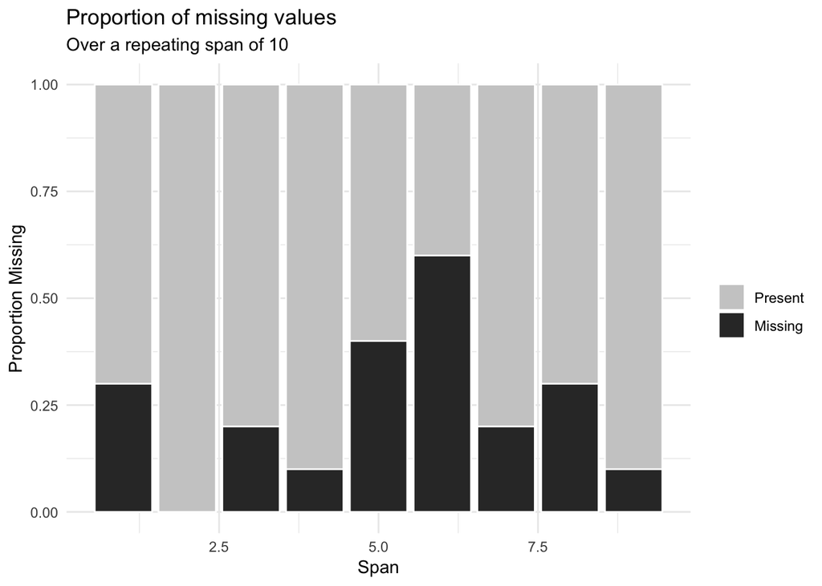

```r
gg_miss_span(msleep, sleep_rem, span_every = 10)
```

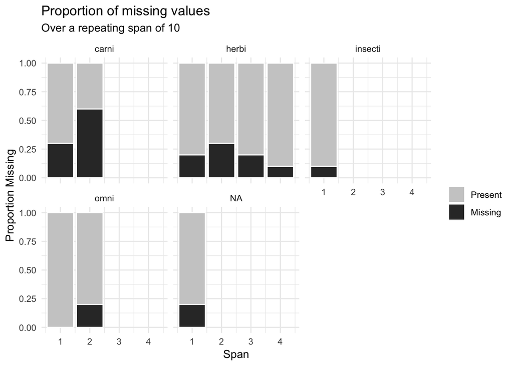

```r
gg_miss_span(msleep, sleep_rem, span_every = 10, facet = vore)
```